# IODS course project

## MCA

Let’s then conduct multiple correspondence analysis.

```r
mca <- MCA(tea_time, graph = FALSE)
summary(mca)
```

```
##
## Call:
## MCA(X = tea_time, graph = FALSE)
##
##
## Eigenvalues
##                        Dim.1   Dim.2   Dim.3   Dim.4   Dim.5   Dim.6   Dim.7
## Variance               0.279   0.261   0.219   0.189   0.177   0.156   0.144
## % of var.             15.238  14.232  11.964  10.333   9.667   8.519   7.841
## Cumulative % of var.  15.238  29.471  41.435  51.768  61.434  69.953  77.794
##                        Dim.8   Dim.9  Dim.10  Dim.11
## Variance               0.141   0.117   0.087   0.062
## % of var.              7.705   6.392   4.724   3.385
## Cumulative % of var.  85.500  91.891  96.615 100.000
##
## Individuals (the 10 first)
##                       Dim.1    ctr   cos2    Dim.2    ctr   cos2    Dim.3
## 1                  | -0.298  0.106  0.086 | -0.328  0.137  0.105 | -0.327
## 2                  | -0.237  0.067  0.036 | -0.136  0.024  0.012 | -0.695
## 3                  | -0.369  0.162  0.231 | -0.300  0.115  0.153 | -0.202
## 4                  | -0.530  0.335  0.460 | -0.318  0.129  0.166 |  0.211
## 5                  | -0.369  0.162  0.231 | -0.300  0.115  0.153 | -0.202
## 6                  | -0.369  0.162  0.231 | -0.300  0.115  0.153 | -0.202
## 7                  | -0.369  0.162  0.231 | -0.300  0.115  0.153 | -0.202
## 8                  | -0.237  0.067  0.036 | -0.136  0.024  0.012 | -0.695
## 9                  |  0.143  0.024  0.012 |  0.871  0.969  0.435 | -0.067
## 10                 |  0.476  0.271  0.140 |  0.687  0.604  0.291 | -0.650
##                       ctr   cos2
## 1                   0.163  0.104 |
## 2                   0.735  0.314 |
## 3                   0.062  0.069 |
## 4                   0.068  0.073 |
## 5                   0.062  0.069 |
## 6                   0.062  0.069 |
## 7                   0.062  0.069 |
## 8                   0.735  0.314 |
## 9                   0.007  0.003 |
## 10                  0.643  0.261 |
##
## Categories (the 10 first)
```

[output cut: 16 more lines]

```
## lemon                3.226 |   1.329  14.771   0.218   8.081 |
## milk                 2.422 |   0.013   0.003   0.000   0.116 |
## other                5.534 |  -2.524  14.526   0.197  -7.676 |
## tea bag             -6.941 |  -0.065   0.183   0.006  -1.287 |
## tea bag+unpackaged  11.956 |   0.019   0.009   0.000   0.226 |
## unpackaged          -6.482 |   0.257   0.602   0.009   1.640 |
##
## Categorical variables (eta2)
##                      Dim.1 Dim.2 Dim.3
## Tea                | 0.126 0.108 0.410 |
## How                | 0.076 0.190 0.394 |
## how                | 0.708 0.522 0.010 |
## sugar              | 0.065 0.001 0.336 |
## where              | 0.702 0.681 0.055 |
## lunch              | 0.000 0.064 0.111 |
```

There are not a couple of super exlaining variables in the plot. The first two variables explain 29% of the variation.

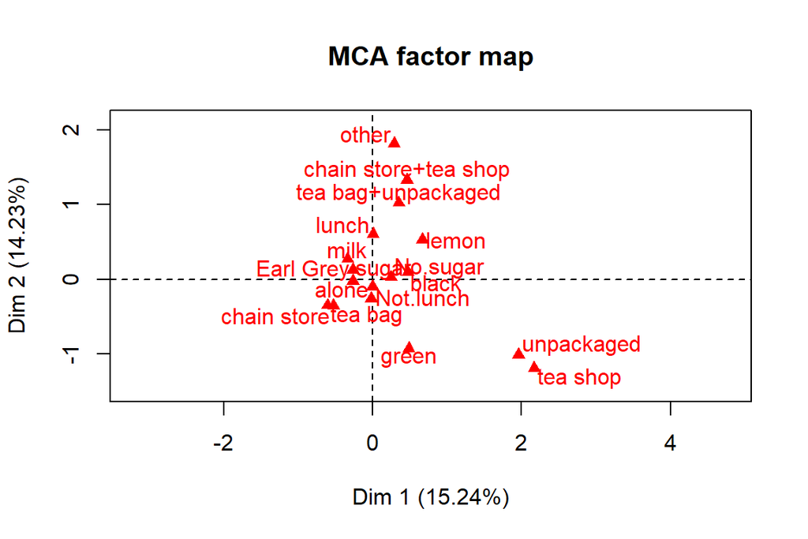

```r
plot(mca, invisible=c("ind"), graph.type = "classic")
```

On the first dimension it can be seen that unpackaged and tea shop - categories stand out as they are more on the right, separated from the rest of the group. On the dim2 the other-variable is on the top. On the bottom teashop, unpackaged and green are quite far from rest of the group. If I interpret this correctly, there is a profile for respondents who choose the other option (from milk, lemon etc, quetion) and then don’t choose tea shop, unpackaged or green option. This applies for the dim 2. With dim 1, there is a certain type of respondent who buy unpackaged tea from tea shop. This kind of profile explains the most of the variation in the data set.

Let’s use fviz_scree plot from “factoextra”-package to visualize the dimensions and their percentage of explained variance with a scree plot.

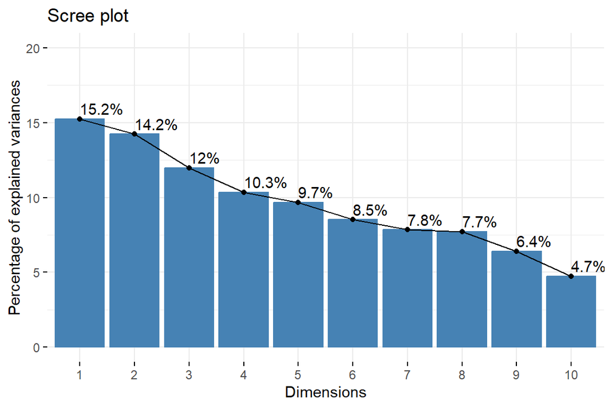

```r
fviz_screeplot(mca, addlabels = TRUE, ylim = c(0, 20))
```

This plot also confirms that there are quite a lot of dimensions and not a single that jumps up and explains most of the variation.

Let’s try one more plotting option.

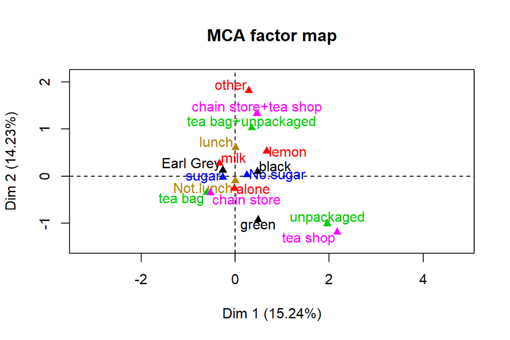

```r
plot(mca, invisible=c("ind"), graph.type = "classic", habillage = "quali")
```

I guess habillage-argument separates answers based on the answers so for example “unpackaged” and “tea bag+unpackaged” are answers to the same question.

I wish I had more time to try to out different methods and plots and such, but for now, I have to leave the analysis to this.